# 市场观察

2016/10/25

## 一、指数估值

### (一)指数动态市盈率

核心指数成分股的动态市盈率中位数走势如下图所示：

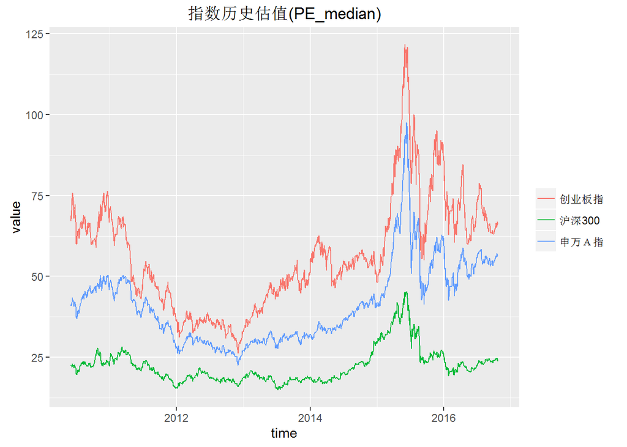

### (二)指数动态市盈率百分位

核心指数上述数据的百分位走势如下图所示：

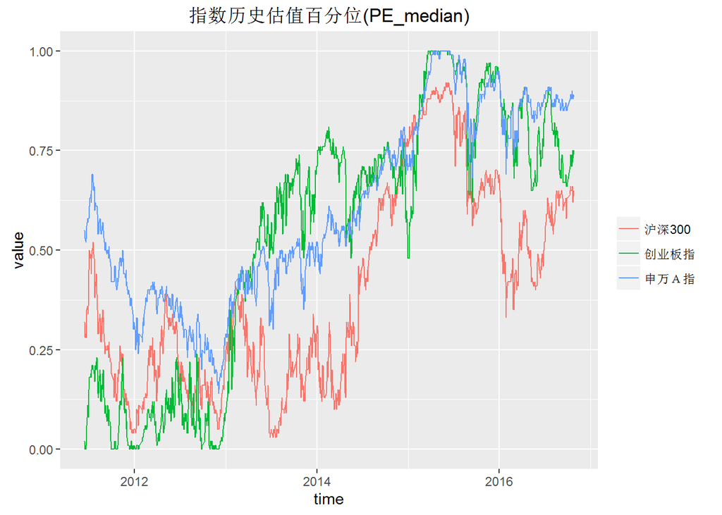

### (三)指数估值概览

纳入观察的18只指数最新的估值情况如下表：

| 日期 | 指数代码 | 指数简称 | 动态市盈率 | 上周动态市盈率 | 市盈率百分位 | 上周市盈率百分位 | 动态市净率 | 市净率百分位 |
| --- | --- | --- | --- | --- | --- | --- | --- | --- |
| 2016-10-24 | EI000979 | 大宗商品 | 53.19 | 52.75 | 0.98 | 0.98 | 2.66 | 0.57 |
| 2016-10-24 | EI000805 | A股资源 | 59.23 | 51.75 | 0.95 | 0.86 | 2.56 | 0.61 |
| 2016-10-24 | EI801003 | 申万Ａ指 | 56.49 | 55.97 | 0.89 | 0.88 | 5.00 | 0.81 |
| 2016-10-24 | EI000819 | 有色金属 | 64.46 | 63.60 | 0.88 | 0.88 | 3.83 | 0.76 |
| 2016-10-24 | EI399005 | 中小板指P | 47.50 | 46.33 | 0.84 | 0.82 | 5.33 | 0.62 |
| 2016-10-24 | EI399330 | 深证100 | 36.61 | 36.19 | 0.82 | 0.81 | 4.34 | 0.71 |
| 2016-10-24 | EI000933 | 中证医药 | 42.51 | 42.44 | 0.81 | 0.81 | 4.70 | 0.46 |
| 2016-10-24 | EI000808 | 医药生物 | 42.87 | 42.58 | 0.80 | 0.78 | 5.42 | 0.61 |
| 2016-10-24 | EI399959 | 军工指数 | 91.75 | 91.75 | 0.76 | 0.77 | 5.80 | 0.71 |
| 2016-10-24 | EI000998 | 中证TMT | 58.33 | 57.95 | 0.75 | 0.74 | 6.29 | 0.78 |
| 2016-10-24 | EI399006 | 创业板指 | 66.69 | 65.12 | 0.75 | 0.71 | 7.75 | 0.78 |
| 2016-10-24 | EI000300 | 沪深300 | 24.40 | 24.40 | 0.65 | 0.65 | 2.58 | 0.48 |
| 2016-10-24 | EI000934 | 中证金融 | 18.94 | 18.79 | 0.63 | 0.62 | 2.20 | 0.46 |
| 2016-10-24 | EI000905 | 中证500 | 38.92 | 38.08 | 0.61 | 0.57 | 3.58 | 0.57 |
| 2016-10-24 | EI000016 | 上证50 | 17.28 | 15.67 | 0.57 | 0.42 | 1.69 | 0.18 |
| 2016-10-24 | EI000827 | 中证环保 | 39.90 | 42.60 | 0.57 | 0.72 | 3.92 | 0.66 |
| 2016-10-24 | EI801120 | 申万食品饮料 | 38.95 | 38.94 | 0.48 | 0.47 | 4.85 | 0.69 |
| 2016-10-24 | EI000932 | 中证消费 | 30.91 | 31.13 | 0.39 | 0.41 | 4.14 | 0.37 |

## 二、基差

### (一)基差走势

三大股指期货隔季合约基差走势如下图：

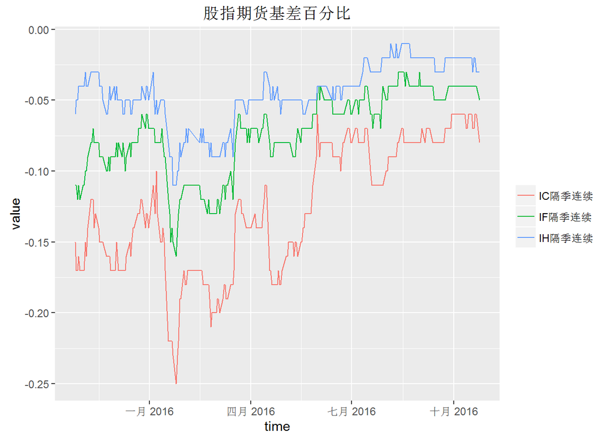

### (二)基差概况

三大股指期货连续合约基差概况如下表：

| 日期 | 合约简称 | 合约收盘价 | 基差 | 基差百分比 | 上周基差 | 上周基差百分比 |
| --- | --- | --- | --- | --- | --- | --- |
| 2016-10-24 | IH当月连续 | 2258.8 | -12.15 | -0.01 | -6.68 | 0.00 |
| 2016-10-24 | IH下月连续 | 2250.2 | -20.75 | -0.01 | -17.08 | -0.01 |
| 2016-10-24 | IH下季连续 | 2224.6 | -46.35 | -0.02 | -27.08 | -0.01 |
| 2016-10-24 | IH隔季连续 | 2205.8 | -65.15 | -0.03 | -53.88 | -0.02 |
| 2016-10-24 | IF当月连续 | 3344.2 | -23.38 | -0.01 | -6.88 | 0.00 |
| 2016-10-24 | IF下月连续 | 3324.0 | -43.58 | -0.01 | -56.28 | -0.02 |
| 2016-10-24 | IF下季连续 | 3256.2 | -111.38 | -0.03 | -63.88 | -0.02 |
| 2016-10-24 | IF隔季连续 | 3215.6 | -151.98 | -0.05 | -141.68 | -0.04 |
| 2016-10-24 | IC当月连续 | 6471.4 | -68.07 | -0.01 | 4.85 | 0.00 |
| 2016-10-24 | IC下月连续 | 6394.0 | -145.47 | -0.02 | -89.15 | -0.01 |
| 2016-10-24 | IC下季连续 | 6176.6 | -362.87 | -0.06 | -174.95 | -0.03 |
| 2016-10-24 | IC隔季连续 | 6008.2 | -531.27 | -0.08 | -404.35 | -0.06 |

## 三、套利

### (一)复牌股票套利

近两天复牌股票套利情况如下表：

| 基金代码 | 基金简称 | 基金类型 | 复牌股票简称 | 停牌时占指数比重 | 停牌日期 | 复牌日期 | 所属行业 | 停牌期间行业涨跌幅 | 停牌前场内份额 | 复牌后场内份额 | 预估最新权重 |
| --- | --- | --- | --- | --- | --- | --- | --- | --- | --- | --- | --- |
| 161721 | 招商沪深300地产 | SF | 城投控股 | 7.58 | 2016-06-20 | 2016-10-24 | AMAC地产 | 0.16 | 2.13 | 2.31 | 6.99 |

### (二)定增基金跟踪

截止2016-10-25定增基金数据如下表，明细数据参见钱瀚的模板。

| 代码 | 名称 | 到期日期 | 最新净值 | 昨日收盘价 | 折溢价率 | 整体隐含折价率 | 大盘回撤0.1净值回撤 |
| --- | --- | --- | --- | --- | --- | --- | --- |
| 168101.OF | 九泰锐智 | 20200814 | 1.43 | 1.35 | -0.05 | 0.07 | -0.06 |
| 168102.OF | 九泰锐富 | 20210204 | 1.04 | 1.00 | -0.04 | 0.15 | 0.11 |
| 161225.OF | 国投瑞盈 | 20161119 | 1.06 | 1.04 | -0.02 | 0.01 | -0.08 |
| 501001.OF | 财通精选 | 20170101 | 1.08 | 1.04 | -0.04 | 0.00 | -0.09 |
| 501015.OF | 财通升级 | 20170908 | 1.05 | 1.00 | -0.05 | 0.09 | -0.05 |
| 160518.OF | 博时睿远 | 20171016 | 1.02 | 0.99 | -0.02 | 0.13 | 0.03 |

定增基金近期的净值走势如下图：

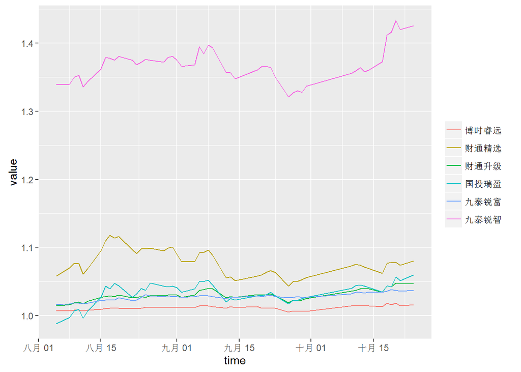

定增基金近期的折溢价走势如下图：

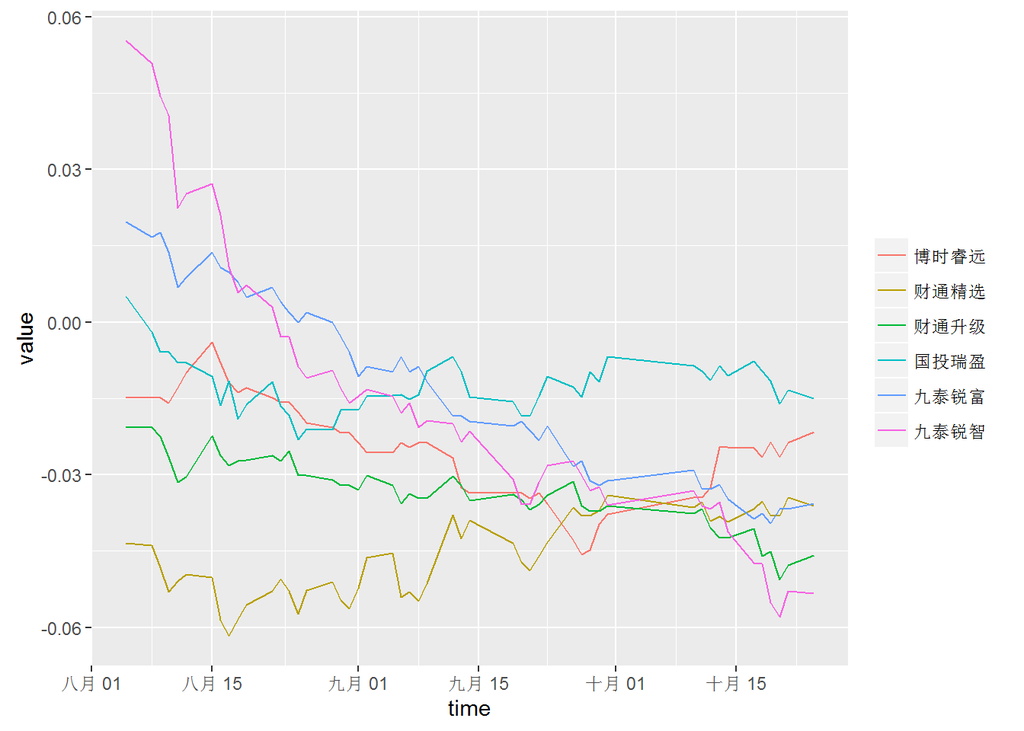

## 四、择时

### (一)大盘均线强弱指数

大盘均线强弱指数在一定程度上可以视为一个反转指标，当大盘均线得分接近8分时，预示市场接近顶部，当大盘均线得分接近0分时，预示市场接近底部。  
大盘均线强弱指数近一年来走势如下图：

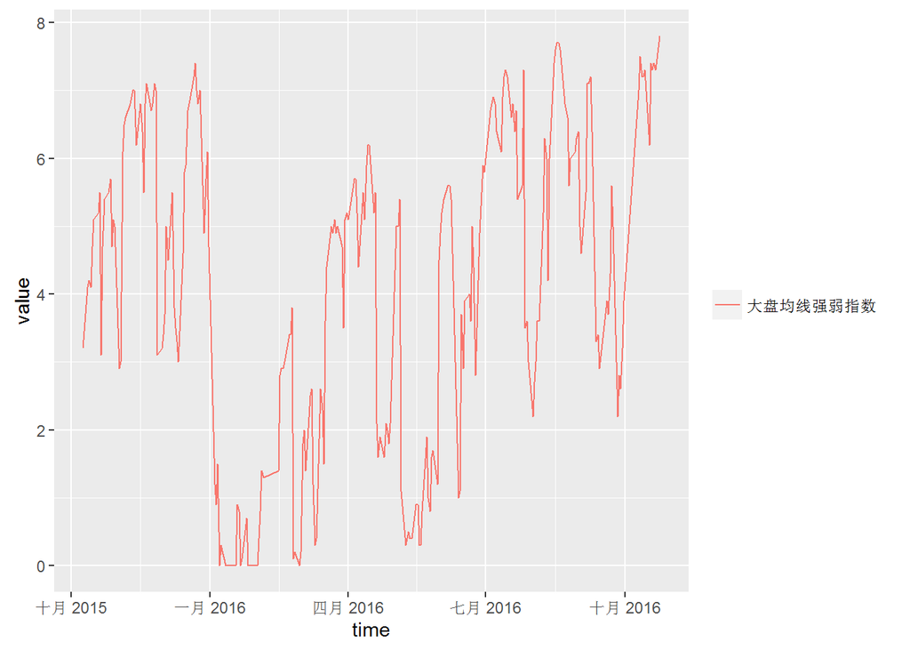

申万一级行业的最新得分及上周得分见下表：

| 日期 | 指数代码 | 指数名称 | 最新值 | 上周值 |
| --- | --- | --- | --- | --- |
| 2016-10-24 | EI801010 | 申万农林牧渔 | 8 | 8 |
| 2016-10-24 | EI801020 | 申万采掘 | 8 | 8 |
| 2016-10-24 | EI801030 | 申万化工 | 8 | 8 |
| 2016-10-24 | EI801040 | 申万钢铁 | 8 | 8 |
| 2016-10-24 | EI801080 | 申万电子 | 8 | 7 |
| 2016-10-24 | EI801110 | 申万家用电器 | 8 | 6 |
| 2016-10-24 | EI801120 | 申万食品饮料 | 8 | 6 |
| 2016-10-24 | EI801130 | 申万纺织服装 | 8 | 8 |
| 2016-10-24 | EI801140 | 申万轻工制造 | 8 | 8 |
| 2016-10-24 | EI801150 | 申万医药生物 | 8 | 8 |
| 2016-10-24 | EI801160 | 申万公用事业 | 8 | 6 |
| 2016-10-24 | EI801180 | 申万房地产 | 8 | 5 |
| 2016-10-24 | EI801200 | 申万商业贸易 | 8 | 6 |
| 2016-10-24 | EI801210 | 申万休闲服务 | 8 | 6 |
| 2016-10-24 | EI801230 | 申万综合 | 8 | 8 |
| 2016-10-24 | EI801710 | 申万建筑材料 | 8 | 7 |
| 2016-10-24 | EI801720 | 申万建筑装饰 | 8 | 8 |
| 2016-10-24 | EI801730 | 申万电气设备 | 8 | 8 |
| 2016-10-24 | EI801770 | 申万通信 | 8 | 7 |
| 2016-10-24 | EI801780 | 申万银行 | 8 | 3 |
| 2016-10-24 | EI801790 | 申万非银金融 | 8 | 2 |
| 2016-10-24 | EI801880 | 申万汽车 | 8 | 7 |
| 2016-10-24 | EI801890 | 申万机械设备 | 8 | 8 |
| 2016-10-24 | EI801050 | 申万有色金属 | 7 | 5 |
| 2016-10-24 | EI801170 | 申万交通运输 | 7 | 5 |
| 2016-10-24 | EI801740 | 申万国防军工 | 7 | 4 |
| 2016-10-24 | EI801750 | 申万计算机 | 7 | 3 |
| 2016-10-24 | EI801760 | 申万传媒 | 6 | 0 |

### (二)LLT及均线择时

LLT本质上是一个改进的单均线择时指标，较原始的均线择时延迟更低。  
择时模型和指数本身的净值走势如下图：

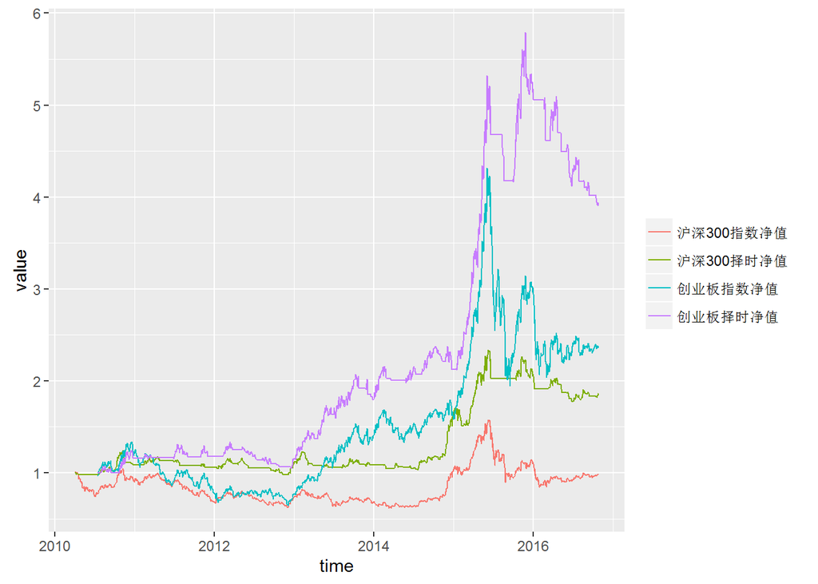

择时模型和指数的收益率统计如下表：

|  | 沪深300指 | 沪深300LLT | 创业板指 | 创业板MA |
| --- | --- | --- | --- | --- |
| 年化收益率 | 0.00 | 0.10 | 0.15 | 0.25 |
| 年化波动率 | 0.25 | 0.16 | 0.34 | 0.24 |
| 年化Sharpe值 | 0.00 | 0.64 | 0.45 | 1.07 |
| 最大回撤 | 0.47 | 0.24 | 0.55 | 0.33 |

择时模型最近10个交易日的信号如下表：

| 日期 | 沪深300收盘价 | 沪深300择时信号 | 创业板收盘价 | 创业板择时信号 |
| --- | --- | --- | --- | --- |
| 2016-10-11 | 3306.557 | buy | 2210.861 | hold |
| 2016-10-12 | 3300.010 | hold | 2209.685 | hold |
| 2016-10-13 | 3302.646 | hold | 2208.567 | hold |
| 2016-10-14 | 3305.848 | hold | 2194.227 | hold |
| 2016-10-17 | 3277.879 | hold | 2167.862 | sell |
| 2016-10-18 | 3321.332 | hold | 2198.141 | buy |
| 2016-10-19 | 3316.241 | hold | 2184.910 | hold |
| 2016-10-20 | 3318.604 | hold | 2193.255 | hold |
| 2016-10-21 | 3327.740 | hold | 2180.996 | hold |
| 2016-10-24 | 3367.578 | hold | 2200.803 | hold |

### (三)网格交易

在经历了三轮股灾，A股逐步回归正常，在过去的一段时间呈现一个震荡的格局，如果未来没有增量信息，很可能维持震荡。结合股指期货的贴水，前期研究了一下网格交易。网格交易的结果如下图：

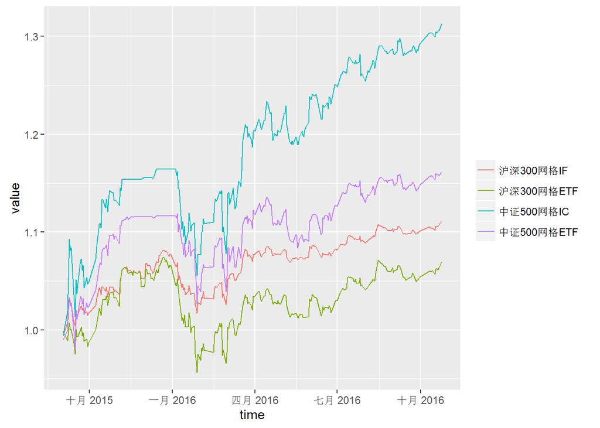

网格交易的收益统计如下表：

|  | 沪深300指数 | 沪深300网格IF | 沪深300网格ETF | 中证500指数 | 中证500网格IC | 中证500网格ETF |
| --- | --- | --- | --- | --- | --- | --- |
| 年化收益率 | 0.00 | 0.10 | 0.06 | 0.05 | 0.28 | 0.15 |
| 年化波动率 | 0.26 | 0.07 | 0.11 | 0.35 | 0.16 | 0.13 |
| 年化Sharpe值 | 0.01 | 1.40 | 0.57 | 0.16 | 1.79 | 1.16 |
| 最大回撤 | 0.26 | 0.06 | 0.11 | 0.33 | 0.09 | 0.08 |

### (四)银行股轮动

银行股轮动是参考集思录的热门贴银行股评级而来的，数据的提取和参数的设置和原贴有一定的差别，所以轮动的效果也会不太一样，不过回测的效果还不错，从现在开始跟踪。2012年以来银行股轮动的结果如下图：

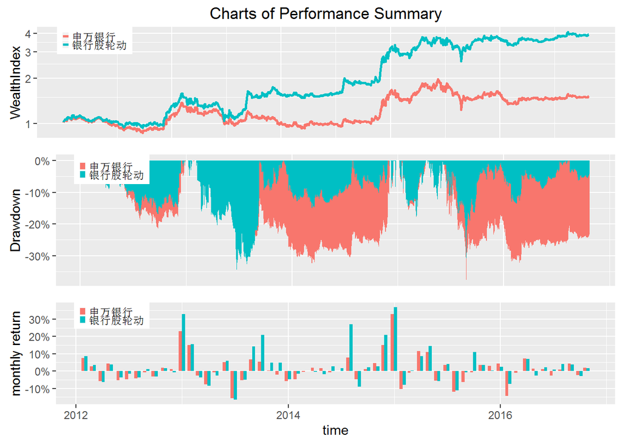

银行股轮动的收益统计如下表：

|  | 申万银行 | 银行股轮动 |
| --- | --- | --- |
| 2012-01-05 ~ 2012-12-31 | 0.14 | 0.31 |
| 2013-01-04 ~ 2013-12-31 | -0.10 | 0.20 |
| 2014-01-02 ~ 2014-12-31 | 0.61 | 1.02 |
| 2015-01-05 ~ 2015-12-31 | -0.03 | 0.17 |
| 2016-01-04 ~ 2016-10-24 | -0.05 | 0.06 |
| Cumulative Return | 0.53 | 2.94 |
| Annualized Return | 0.10 | 0.35 |

银行股轮动的最新得分如下表：

| 日期 | 代码 | 简称 | PB | 预期ROE | 翻倍期 | 持仓 |
| --- | --- | --- | --- | --- | --- | --- |
| 2016-10-24 | EQ601988 | 中国银行 | 0.77 | 0.12 | 3.74 | hold |
| 2016-10-24 | EQ600015 | 华夏银行 | 0.87 | 0.15 | 4.04 |  |
| 2016-10-24 | EQ601818 | 光大银行 | 0.80 | 0.12 | 4.09 |  |
| 2016-10-24 | EQ601328 | 交通银行 | 0.78 | 0.11 | 4.17 |  |
| 2016-10-24 | EQ601288 | 农业银行 | 0.84 | 0.13 | 4.17 |  |
| 2016-10-24 | EQ601398 | 工商银行 | 0.88 | 0.14 | 4.38 |  |
| 2016-10-24 | EQ000001 | 平安银行 | 0.86 | 0.13 | 4.49 |  |
| 2016-10-24 | EQ601939 | 建设银行 | 0.91 | 0.14 | 4.53 |  |
| 2016-10-24 | EQ601166 | 兴业银行 | 0.98 | 0.15 | 4.85 |  |
| 2016-10-24 | EQ600000 | 浦发银行 | 1.09 | 0.15 | 5.59 |  |
| 2016-10-24 | EQ601998 | 中信银行 | 0.95 | 0.12 | 5.74 |  |
| 2016-10-24 | EQ600016 | 民生银行 | 1.12 | 0.14 | 6.14 |  |
| 2016-10-24 | EQ600036 | 招商银行 | 1.26 | 0.15 | 6.62 |  |
| 2016-10-24 | EQ601009 | 南京银行 | 1.26 | 0.14 | 6.95 |  |
| 2016-10-24 | EQ601169 | 北京银行 | 1.22 | 0.14 | 6.97 |  |
| 2016-10-24 | EQ002142 | 宁波银行 | 1.35 | 0.15 | 7.06 |  |